# Practice Activity 9.2

Our dataset consists of clinical data from patients who entered the hospital complaining of chest pain (“angina”) during exercise. The information collected includes:

- `age` : Age of the patient
- `sex` : Sex of the patient
- `cp` : Chest Pain type
  - Value 0: asymptomatic
  - Value 1: typical angina
  - Value 2: atypical angina
  - Value 3: non-anginal pain
- `trtbps` : resting blood pressure (in mm Hg)
- `chol` : cholesterol in mg/dl fetched via BMI sensor
- `restecg` : resting electrocardiographic results
  - Value 0: normal
  - Value 1: having ST-T wave abnormality (T wave inversions and/or ST elevation or depression of > 0.05 mV)
  - Value 2: showing probable or definite left ventricular hypertrophy by Estes’ criteria
- `thalach` : maximum heart rate achieved during exercise
- `output` : the doctor’s diagnosis of whether the patient is at risk for a heart attack
  - 0 = not at risk of heart attack
  - 1 = at risk of heart attack

```python
## library imports here
import numpy as np
import pandas as pd
from sklearn.pipeline import Pipeline
from sklearn.neighbors import KNeighborsClassifier
from sklearn.tree import DecisionTreeClassifier
from sklearn.linear_model import LogisticRegression
from sklearn.compose import make_column_selector, ColumnTransformer
from sklearn.preprocessing import StandardScaler, OneHotEncoder
from sklearn.model_selection import cross_val_score
from sklearn.tree import plot_tree
```

```python
ha = pd.read_csv("https://www.dropbox.com/s/aohbr6yb9ifmc8w/heart_attack.csv?dl=1")
```

## Q1: Natural Multiclass Models

Fit a multiclass KNN, Decision Tree, and LDA for the heart disease data; this time predicting the type of chest pain (categories 0 - 3) that a patient experiences. For the decision tree, plot the fitted tree, and interpret the first couple splits.

```python
ha["sex"] = ha["sex"].astype("category")
ha["cp"] = ha["cp"].astype("category")
ha["restecg"] = ha["restecg"].astype("category")
ha["output"] = ha["output"].astype("category")
```

```python
ha["cp3"] = (ha["cp"] == 3) * 1
ha["cp2"] = (ha["cp"] == 2) * 1
ha["cp1"] = (ha["cp"] == 1) * 1
ha["cp0"] = (ha["cp"] == 0) * 1
```

```python
ha["cp"] = ha["cp"].astype("str")
```

```python
ha.head()
```

|  | age | sex | cp | trtbps | chol | restecg | thalach | output | cp3 | cp2 | cp1 | cp0 |
| --- | --- | --- | --- | --- | --- | --- | --- | --- | --- | --- | --- | --- |
| 0 | 63 | 1 | 3 | 145 | 233 | 0 | 150 | 1 | 1 | 0 | 0 | 0 |
| 1 | 37 | 1 | 2 | 130 | 250 | 1 | 187 | 1 | 0 | 1 | 0 | 0 |
| 2 | 56 | 1 | 1 | 120 | 236 | 1 | 178 | 1 | 0 | 0 | 1 | 0 |
| 3 | 57 | 0 | 0 | 120 | 354 | 1 | 163 | 1 | 0 | 0 | 0 | 1 |
| 4 | 57 | 1 | 0 | 140 | 192 | 1 | 148 | 1 | 0 | 0 | 0 | 1 |

```python
X_train = ha[["age", "sex", "output", "trtbps", "chol", "restecg", "thalach"]]
y_train = ha["cp"]
```

```python
ct = ColumnTransformer(
  [
    ("dummify",
    OneHotEncoder(sparse_output = False, handle_unknown='ignore'),
    make_column_selector(dtype_include=["category"])),
    ("standardize",
    StandardScaler(),
    make_column_selector(dtype_include=np.number))
  ],
  remainder = "passthrough"
)
```

```python
KNNpipeline = Pipeline(
  [("preprocessing", ct),
  ("KNN_classifier", KNeighborsClassifier(n_neighbors = 35))]
)
```

```python
scores = cross_val_score(KNNpipeline, X_train, y_train, cv=5, scoring='accuracy')
```

```python
scores.mean()
```

```
np.float64(0.534882154882155)
```

```python
decisionpipeline =Pipeline(
    [("preprocessing", ct),
    ("tree_classifier", DecisionTreeClassifier(max_depth=2))]
)
```

```python
decisionpipeline.fit(X_train, y_train)
```

```
Pipeline(steps=[('preprocessing',
                 ColumnTransformer(remainder='passthrough',
                                   transformers=[('dummify',
                                                  OneHotEncoder(handle_unknown='ignore',
                                                                sparse_output=False),
                                                  <sklearn.compose._column_transformer.make_column_selector object at 0x000001C881673E00>),
                                                 ('standardize',
                                                  StandardScaler(),
                                                  <sklearn.compose._column_transformer.make_column_selector object at 0x000001C8816B1310>)])),
                ('tree_classifier', DecisionTreeClassifier(max_depth=2))])
```

[output not shown]

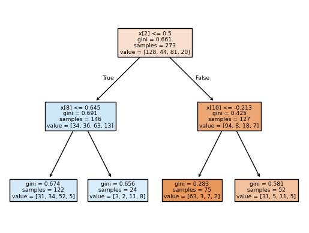

```python
plot_tree(decisionpipeline.named_steps["tree_classifier"], filled=True)
```

The initial split is separating the population by high risk and not high risk, which is the most prevalent predictor.

## Q2: OvR

Create a new column in the `ha` dataset called `cp_is_3`, which is equal to `1` if the `cp` variable is equal to `3` and `0` otherwise.

Then, fit a Logistic Regression to predict this new target, and report the **F1 Score**.

Repeat for the other three `cp` categories. Which category was the OvR approach best at distinguishing?

```python
y3 = ha["cp3"]
y2 = ha["cp2"]
y1 = ha["cp1"]
y0 = ha["cp0"]
```

```python
logistic_model =Pipeline(
    [("scale", StandardScaler()),
    ("model", LogisticRegression())]
)
```

```python
logistic_model.fit(X_train, y3)
```

```
Pipeline(steps=[('scale', StandardScaler()), ('model', LogisticRegression())])
```

```python
cross_val_score(logistic_model, X_train, y3, cv=5, scoring="f1").mean()
```

```
np.float64(0.0)
```

```python
cross_val_score(logistic_model, X_train, y2, cv=5, scoring="f1").mean()
```

```
np.float64(0.1393939393939394)
```

```python
cross_val_score(logistic_model, X_train, y1, cv=5, scoring="f1").mean()
```

```
np.float64(0.0)
```

```python
cross_val_score(logistic_model, X_train, y0, cv=5, scoring="f1").mean()
```

```
np.float64(0.6525962644949986)
```

After looking F1 scores, I can conclude that the best model had the target “cp0”

## Q3: OvO

Reduce your dataset to only the `0` and `1` types of chest pain.

Then, fit a Logistic Regression to predict between the two groups, and report the **ROC-AUC**.

Repeat comparing category `0` to `2` and `3`. Which pair was the OvO approach best at distinguishing?

```python
ha01 = ha[(ha["cp"] == "0") | (ha["cp"] == "1")]
ha02 = ha[(ha["cp"] == "0") | (ha["cp"] == "2")]
ha03 = ha[(ha["cp"] == "0") | (ha["cp"] == "3")]
```

```python
y01 = ha01["cp"]
X01 = ha01[["age", "sex", "output", "trtbps", "chol", "restecg", "thalach"]]
```

```python
y02 = ha02["cp"]
X02 = ha02[["age", "sex", "output", "trtbps", "chol", "restecg", "thalach"]]
```

```python
y03 = ha03["cp"]
X03 = ha03[["age", "sex", "output", "trtbps", "chol", "restecg", "thalach"]]
```

```python
logistic_model =Pipeline(
    [("scale", StandardScaler()),
    ("model", LogisticRegression())]
)
```

```python
logistic_model.fit(X01, y01)
```

```
Pipeline(steps=[('scale', StandardScaler()), ('model', LogisticRegression())])
```

```python
cross_val_score(logistic_model, X01, y01, cv=5, scoring="roc_auc").mean()
```

```
np.float64(0.8376709401709401)
```

```python
cross_val_score(logistic_model, X02, y02, cv=5, scoring="roc_auc").mean()
```

```
np.float64(0.7511029411764706)
```

```python
cross_val_score(logistic_model, X03, y03, cv=5, scoring="roc_auc").mean()
```

```
np.float64(0.7412307692307692)
```

Using the OvO approach, the best pair was 0/1